# GSE544 homework 5 part 1

Bishwa R. Rai with Claude Sonnet 4.6

2026-05-11

*LLM disclaimer: Claude Sonnet 4.6 was used to assist in writing code and to check solutions.

## Fitting marginals and copulas to the VMLS portfolio

```r
library(tidyverse)
library(MASS)       # fitdistr
library(mvtnorm)    # rmvnorm, dmvnorm
library(copula)     # tCopula, normalCopula, fitCopula, rCopula
```

```r
returns <- read_csv("C:/Users/Bishw/Desktop/DA/vmls_portfolio_returns.csv")
# Training set: first 2000 rows, risky assets 1-19 (first 19 of 20 columns)
train <- returns[1:2000, 1:19]
colnames(train) <- paste0("asset_", 1:19)

# Four-asset subset: stocks 1, 2, 3, 10 (0-indexed [0,1,2,9] => columns 1,2,3,10)
four_assets <- train[, c(1, 2, 3, 10)]
colnames(four_assets) <- c("stock_1", "stock_2", "stock_3", "stock_10")
```

### a) Student-t marginals

```r
# Fit Student-t to each of the 19 assets
# fitdistr returns names like "df.df", "loc.m", "scale.s" — store raw and index by grepl
fit_t <- function(x) fitdistr(x, "t")$estimate

marginal_params <- lapply(train, fit_t)

# Build summary table
marginal_params_df <- do.call(rbind, lapply(marginal_params, function(p) {
  c(df = unname(p["df"]), loc = unname(p["m"]), scale = unname(p["s"]))
})) %>%
  as_tibble(rownames = "asset")
colnames(marginal_params_df) <- c("asset", "df", "loc", "scale")

# Print summary for stocks 1, 2, 3, 10
marginal_params_df %>%
  filter(asset %in% c("asset_1", "asset_2", "asset_3", "asset_10")) %>%
  knitr::kable(digits = 4, caption = "Student-t marginal fits for stocks 1, 2, 3, 10")
```

Student-t marginal fits for stocks 1, 2, 3, 10

| asset | df | loc | scale |
| --- | --- | --- | --- |
| asset_1 | 1.7858 | 4e-04 | 0.0115 |
| asset_2 | 1.3511 | -2e-04 | 0.0106 |
| asset_3 | 3.0861 | 8e-04 | 0.0122 |
| asset_10 | 4.0148 | 3e-04 | 0.0145 |

### b) PITs and the empirical scatter matrix

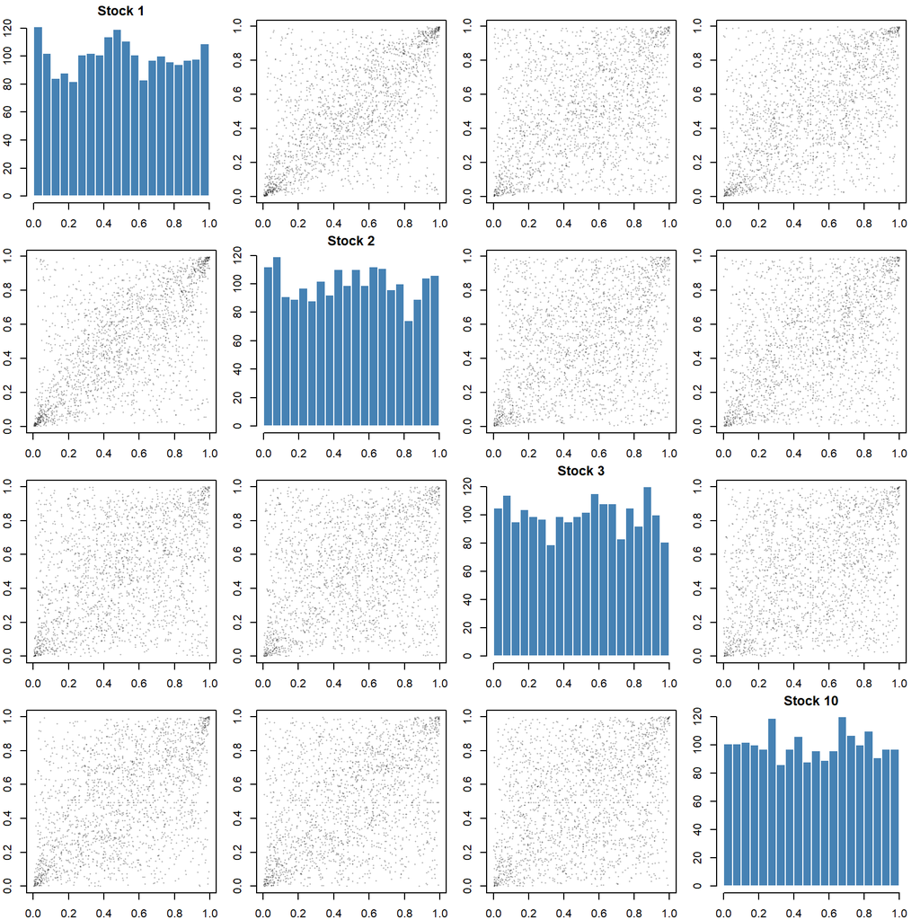

```r
# Apply PIT u = F(r) using fitted Student-t marginals, clip to [1e-6, 1-1e-6]
# fitdistr returns names "m", "s", "df" — use directly
u_all <- matrix(NA_real_, nrow = nrow(train), ncol = 19)
for (i in seq_along(marginal_params)) {
  p         <- marginal_params[[i]]
  raw       <- as.numeric(train[[i]])
  u         <- pt((raw - p["m"]) / p["s"], df = p["df"])
  u_all[, i] <- pmin(pmax(u, 1e-6), 1 - 1e-6)
}
u_all <- as.data.frame(u_all)
colnames(u_all) <- paste0("asset_", 1:19)

# Four-asset PIT subset
u4 <- u_all[, c(1, 2, 3, 10)]
colnames(u4) <- c("stock_1", "stock_2", "stock_3", "stock_10")

# 4x4 empirical PIT scatter matrix
# Diagonal: marginal uniformity histograms; off-diagonal: pairwise scatters
labels <- c("Stock 1", "Stock 2", "Stock 3", "Stock 10")

par(mfrow = c(4, 4), mar = c(2, 2, 1.5, 1))

for (i in 1:4) {
  for (j in 1:4) {
    if (i == j) {
      hist(u4[[i]], breaks = 20, col = "steelblue", border = "white",
           main = labels[i], xlab = "", ylab = "")
    } else {
      plot(u4[[j]], u4[[i]], pch = 16, cex = 0.3, col = rgb(0, 0, 0, 0.3),
           xlab = labels[j], ylab = labels[i], main = "")
    }
  }
}
```

The diagonal histograms are approximately uniform, confirming the Student-$t$ marginals are well-fitted. In the off-diagonal scatters, dependence concentrates in the corners, particularly the lower-left (joint lower tail) and upper-right (joint upper tail), indicating co-movement during extreme market events. This corner concentration is the key empirical pattern that any fitted copula must reproduce.

### c) Gaussian copula

```r
# Fit Gaussian copula on the four-asset subset
# The correlation matrix is the entire dependence structure
u4_mat <- as.matrix(u4)

gauss_cop <- normalCopula(dim = 4, dispstr = "un")
gauss_fit  <- fitCopula(gauss_cop, data = u4_mat, method = "ml")

gauss_cor <- coef(gauss_fit)

# Reconstruct the 4x4 correlation matrix
P_gauss <- diag(4)
idx <- which(lower.tri(P_gauss), arr.ind = TRUE)
for (k in seq_len(nrow(idx))) {
  P_gauss[idx[k, 1], idx[k, 2]] <- gauss_cor[k]
  P_gauss[idx[k, 2], idx[k, 1]] <- gauss_cor[k]
}

rownames(P_gauss) <- colnames(P_gauss) <- labels
P_gauss %>%
  knitr::kable(digits = 4, caption = "Gaussian copula correlation matrix")
```

Gaussian copula correlation matrix

|  | Stock 1 | Stock 2 | Stock 3 | Stock 10 |
| --- | --- | --- | --- | --- |
| Stock 1 | 1.0000 | 0.6613 | 0.4188 | 0.5370 |
| Stock 2 | 0.6613 | 1.0000 | 0.3938 | 0.4687 |
| Stock 3 | 0.4188 | 0.3938 | 1.0000 | 0.4080 |
| Stock 10 | 0.5370 | 0.4687 | 0.4080 | 1.0000 |

### d) t-copula

```r
# Fit t-copula on the four-asset subset
t_cop <- tCopula(dim = 4, dispstr = "un")
t_fit  <- fitCopula(t_cop, data = u4_mat, method = "ml")

t_params <- coef(t_fit)
nu_hat   <- t_params["df"]
cat("Fitted copula degrees of freedom:", round(nu_hat, 4), "\n")
```

```
## Fitted copula degrees of freedom: 3.7628
```

```r
# Compare to marginal dfs
marginal_nu <- marginal_params_df %>%
  filter(asset %in% c("asset_1", "asset_2", "asset_3", "asset_10")) %>%
  dplyr::select(asset, df)
marginal_nu %>%
  knitr::kable(digits = 4, caption = "Marginal Student-t degrees of freedom")
```

Marginal Student-t degrees of freedom

| asset | df |
| --- | --- |
| asset_1 | 1.7858 |
| asset_2 | 1.3511 |
| asset_3 | 3.0861 |
| asset_10 | 4.0148 |

### e) Simulate and compare

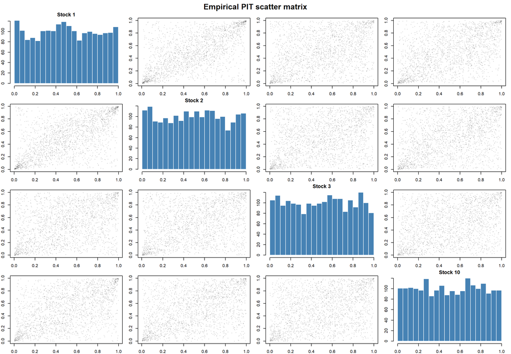

```r
set.seed(544)
n_sim <- 2000

# Simulate from Gaussian copula
u_gauss_sim <- rCopula(n_sim, gauss_fit@copula)

# Simulate from t-copula
u_t_sim     <- rCopula(n_sim, t_fit@copula)

# Helper: plot 4x4 scatter matrix
plot_pit_matrix <- function(u_mat, main_title, col_pts = rgb(0, 0, 0, 0.3)) {
  par(mfrow = c(4, 4), mar = c(2, 2, 1.5, 1), oma = c(0, 0, 2, 0))
  for (i in 1:4) {
    for (j in 1:4) {
      if (i == j) {
        hist(u_mat[, i], breaks = 20, col = "steelblue", border = "white",
             main = labels[i], xlab = "", ylab = "")
      } else {
        plot(u_mat[, j], u_mat[, i], pch = 16, cex = 0.3, col = col_pts,
             xlab = labels[j], ylab = labels[i], main = "")
      }
    }
  }
  mtext(main_title, outer = TRUE, cex = 1.2, font = 2)
}

# Empirical
plot_pit_matrix(u4_mat, "Empirical PIT scatter matrix")
```

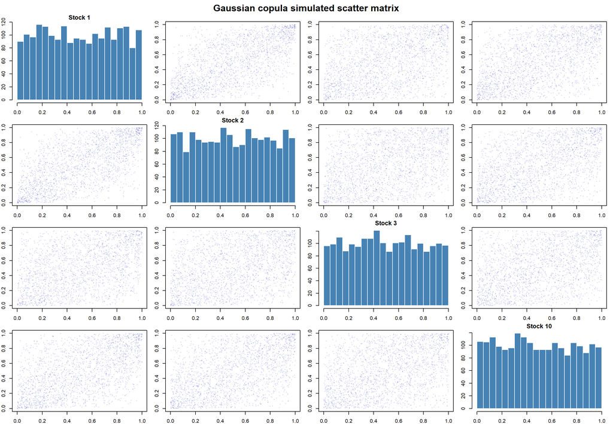

```r
# Gaussian-simulated
plot_pit_matrix(u_gauss_sim, "Gaussian copula simulated scatter matrix",
                col_pts = rgb(0, 0, 0.7, 0.3))
```

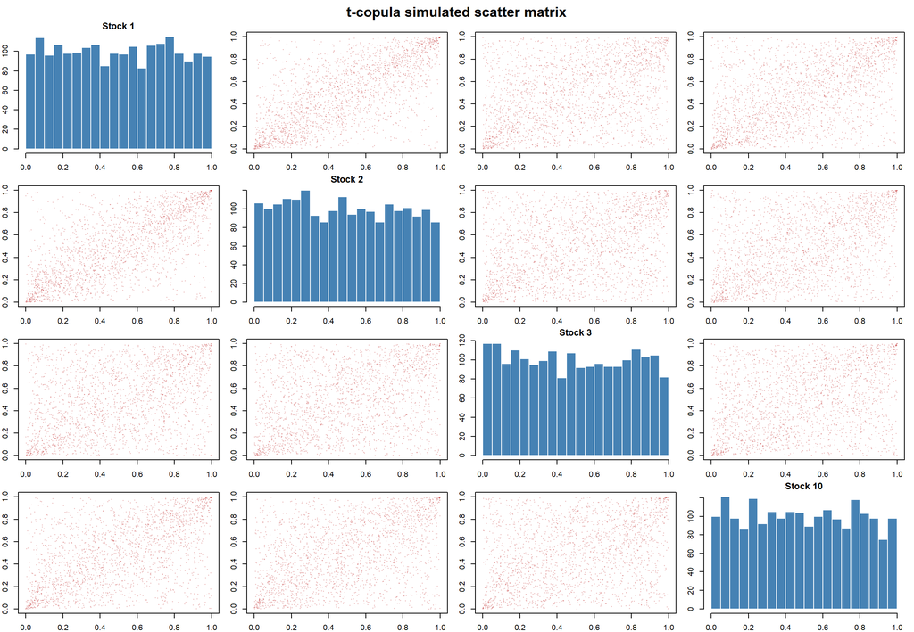

```r
# t-simulated
plot_pit_matrix(u_t_sim, "t-copula simulated scatter matrix",
                col_pts = rgb(0.7, 0, 0, 0.3))
```

The $t$-copula reproduces the empirical corner mass much better than the Gaussian copula. The Gaussian copula scatter fills the interior of the unit square without concentrating in the corners, because a Gaussian copula has zero asymptotic tail dependence, no matter how correlated the margins are, extreme joint events become asymptotically independent. The $t$-copula, by contrast, has positive asymptotic tail dependence governed by its degrees-of-freedom parameter $\hat{\nu}$: when one asset crashes, others are more likely to crash simultaneously. This is the canonical reason finance prefers the $t$-copula, it captures the joint tail co-movement that actually characterizes equity portfolios during market stress, which the Gaussian copula structurally cannot.